# Risk Factor Analysis

## Outcome Variable

**Outcome Variable:** ever_wasted

## Predictor Variables

**Intervention Variable:** month

**Adjustment Set:**

unadjusted

## Stratifying Variables

The analysis was stratified on these variable(s):

- agecat
- studyid
- country

## Data Summary

| agecat | studyid | country | month | ever_wasted | n_cell | n |
| --- | --- | --- | --- | --- | --- | --- |
| 0-24 months (no birth wast) | ki0047075b-MAL-ED | BANGLADESH | 1 | 0 | 18 | 263 |
| 0-24 months (no birth wast) | ki0047075b-MAL-ED | BANGLADESH | 1 | 1 | 3 | 263 |
| 0-24 months (no birth wast) | ki0047075b-MAL-ED | BANGLADESH | 2 | 0 | 17 | 263 |
| 0-24 months (no birth wast) | ki0047075b-MAL-ED | BANGLADESH | 2 | 1 | 7 | 263 |
| 0-24 months (no birth wast) | ki0047075b-MAL-ED | BANGLADESH | 3 | 0 | 15 | 263 |
| 0-24 months (no birth wast) | ki0047075b-MAL-ED | BANGLADESH | 3 | 1 | 12 | 263 |
| 0-24 months (no birth wast) | ki0047075b-MAL-ED | BANGLADESH | 4 | 0 | 18 | 263 |
| 0-24 months (no birth wast) | ki0047075b-MAL-ED | BANGLADESH | 4 | 1 | 4 | 263 |
| 0-24 months (no birth wast) | ki0047075b-MAL-ED | BANGLADESH | 5 | 0 | 16 | 263 |
| 0-24 months (no birth wast) | ki0047075b-MAL-ED | BANGLADESH | 5 | 1 | 6 | 263 |
| 0-24 months (no birth wast) | ki0047075b-MAL-ED | BANGLADESH | 6 | 0 | 7 | 263 |
| 0-24 months (no birth wast) | ki0047075b-MAL-ED | BANGLADESH | 6 | 1 | 2 | 263 |
| 0-24 months (no birth wast) | ki0047075b-MAL-ED | BANGLADESH | 7 | 0 | 16 | 263 |
| 0-24 months (no birth wast) | ki0047075b-MAL-ED | BANGLADESH | 7 | 1 | 6 | 263 |
| 0-24 months (no birth wast) | ki0047075b-MAL-ED | BANGLADESH | 8 | 0 | 24 | 263 |
| 0-24 months (no birth wast) | ki0047075b-MAL-ED | BANGLADESH | 8 | 1 | 1 | 263 |
| 0-24 months (no birth wast) | ki0047075b-MAL-ED | BANGLADESH | 9 | 0 | 13 | 263 |
| 0-24 months (no birth wast) | ki0047075b-MAL-ED | BANGLADESH | 9 | 1 | 10 | 263 |
| 0-24 months (no birth wast) | ki0047075b-MAL-ED | BANGLADESH | 10 | 0 | 21 | 263 |
| 0-24 months (no birth wast) | ki0047075b-MAL-ED | BANGLADESH | 10 | 1 | 3 | 263 |
| 0-24 months (no birth wast) | ki0047075b-MAL-ED | BANGLADESH | 11 | 0 | 15 | 263 |
| 0-24 months (no birth wast) | ki0047075b-MAL-ED | BANGLADESH | 11 | 1 | 2 | 263 |
| 0-24 months (no birth wast) | ki0047075b-MAL-ED | BANGLADESH | 12 | 0 | 25 | 263 |
| 0-24 months (no birth wast) | ki0047075b-MAL-ED | BANGLADESH | 12 | 1 | 2 | 263 |
| 0-24 months (no birth wast) | ki0047075b-MAL-ED | BRAZIL | 1 | 0 | 13 | 232 |
| 0-24 months (no birth wast) | ki0047075b-MAL-ED | BRAZIL | 1 | 1 | 0 | 232 |
| 0-24 months (no birth wast) | ki0047075b-MAL-ED | BRAZIL | 2 | 0 | 24 | 232 |
| 0-24 months (no birth wast) | ki0047075b-MAL-ED | BRAZIL | 2 | 1 | 2 | 232 |
| 0-24 months (no birth wast) | ki0047075b-MAL-ED | BRAZIL | 3 | 0 | 20 | 232 |
| 0-24 months (no birth wast) | ki0047075b-MAL-ED | BRAZIL | 3 | 1 | 1 | 232 |

[output cut: 1962 more lines]

The following strata were considered:

- agecat: 0-24 months (no birth wast), studyid: ki0047075b-MAL-ED, country: BANGLADESH
- agecat: 0-24 months (no birth wast), studyid: ki0047075b-MAL-ED, country: BRAZIL
- agecat: 0-24 months (no birth wast), studyid: ki0047075b-MAL-ED, country: INDIA
- agecat: 0-24 months (no birth wast), studyid: ki0047075b-MAL-ED, country: NEPAL
- agecat: 0-24 months (no birth wast), studyid: ki0047075b-MAL-ED, country: PERU
- agecat: 0-24 months (no birth wast), studyid: ki0047075b-MAL-ED, country: SOUTH AFRICA
- agecat: 0-24 months (no birth wast), studyid: ki0047075b-MAL-ED, country: TANZANIA, UNITED REPUBLIC OF
- agecat: 0-24 months (no birth wast), studyid: ki1000108-CMC-V-BCS-2002, country: INDIA
- agecat: 0-24 months (no birth wast), studyid: ki1000108-IRC, country: INDIA
- agecat: 0-24 months (no birth wast), studyid: ki1000109-EE, country: PAKISTAN
- agecat: 0-24 months (no birth wast), studyid: ki1000109-ResPak, country: PAKISTAN
- agecat: 0-24 months (no birth wast), studyid: ki1000304b-SAS-CompFeed, country: INDIA
- agecat: 0-24 months (no birth wast), studyid: ki1000304b-SAS-FoodSuppl, country: INDIA
- agecat: 0-24 months (no birth wast), studyid: ki1017093-NIH-Birth, country: BANGLADESH
- agecat: 0-24 months (no birth wast), studyid: ki1066203-TanzaniaChild2, country: TANZANIA, UNITED REPUBLIC OF
- agecat: 0-24 months (no birth wast), studyid: ki1112895-Guatemala BSC, country: GUATEMALA
- agecat: 0-24 months (no birth wast), studyid: ki1112895-iLiNS-Zinc, country: BURKINA FASO
- agecat: 0-24 months (no birth wast), studyid: ki1113344-GMS-Nepal, country: NEPAL
- agecat: 0-24 months (no birth wast), studyid: ki1114097-CMIN, country: BANGLADESH
- agecat: 0-24 months (no birth wast), studyid: ki1114097-CMIN, country: BRAZIL
- agecat: 0-24 months (no birth wast), studyid: ki1114097-CMIN, country: GUINEA-BISSAU
- agecat: 0-24 months (no birth wast), studyid: ki1114097-CMIN, country: PERU
- agecat: 0-24 months (no birth wast), studyid: ki1114097-CONTENT, country: PERU
- agecat: 0-24 months (no birth wast), studyid: ki1119695-PROBIT, country: BELARUS
- agecat: 0-24 months (no birth wast), studyid: ki1126311-ZVITAMBO, country: ZIMBABWE
- agecat: 0-24 months (no birth wast), studyid: ki1148112-LCNI-5, country: MALAWI
- agecat: 0-24 months (no birth wast), studyid: kiGH5241-JiVitA-3, country: BANGLADESH
- agecat: 0-24 months (no birth wast), studyid: kiGH5241-JiVitA-4, country: BANGLADESH
- agecat: 0-6 months (no birth wast), studyid: ki0047075b-MAL-ED, country: BANGLADESH
- agecat: 0-6 months (no birth wast), studyid: ki0047075b-MAL-ED, country: BRAZIL
- agecat: 0-6 months (no birth wast), studyid: ki0047075b-MAL-ED, country: INDIA
- agecat: 0-6 months (no birth wast), studyid: ki0047075b-MAL-ED, country: NEPAL
- agecat: 0-6 months (no birth wast), studyid: ki0047075b-MAL-ED, country: PERU
- agecat: 0-6 months (no birth wast), studyid: ki0047075b-MAL-ED, country: SOUTH AFRICA
- agecat: 0-6 months (no birth wast), studyid: ki0047075b-MAL-ED, country: TANZANIA, UNITED REPUBLIC OF
- agecat: 0-6 months (no birth wast), studyid: ki1000108-CMC-V-BCS-2002, country: INDIA
- agecat: 0-6 months (no birth wast), studyid: ki1000108-IRC, country: INDIA
- agecat: 0-6 months (no birth wast), studyid: ki1000109-EE, country: PAKISTAN
- agecat: 0-6 months (no birth wast), studyid: ki1000109-ResPak, country: PAKISTAN
- agecat: 0-6 months (no birth wast), studyid: ki1000304b-SAS-CompFeed, country: INDIA
- agecat: 0-6 months (no birth wast), studyid: ki1000304b-SAS-FoodSuppl, country: INDIA
- agecat: 0-6 months (no birth wast), studyid: ki1017093-NIH-Birth, country: BANGLADESH
- agecat: 0-6 months (no birth wast), studyid: ki1066203-TanzaniaChild2, country: TANZANIA, UNITED REPUBLIC OF
- agecat: 0-6 months (no birth wast), studyid: ki1112895-Guatemala BSC, country: GUATEMALA
- agecat: 0-6 months (no birth wast), studyid: ki1113344-GMS-Nepal, country: NEPAL
- agecat: 0-6 months (no birth wast), studyid: ki1114097-CMIN, country: BANGLADESH
- agecat: 0-6 months (no birth wast), studyid: ki1114097-CMIN, country: BRAZIL
- agecat: 0-6 months (no birth wast), studyid: ki1114097-CMIN, country: GUINEA-BISSAU
- agecat: 0-6 months (no birth wast), studyid: ki1114097-CMIN, country: PERU
- agecat: 0-6 months (no birth wast), studyid: ki1114097-CONTENT, country: PERU
- agecat: 0-6 months (no birth wast), studyid: ki1119695-PROBIT, country: BELARUS
- agecat: 0-6 months (no birth wast), studyid: ki1126311-ZVITAMBO, country: ZIMBABWE
- agecat: 0-6 months (no birth wast), studyid: ki1148112-LCNI-5, country: MALAWI
- agecat: 0-6 months (no birth wast), studyid: kiGH5241-JiVitA-3, country: BANGLADESH
- agecat: 0-6 months (no birth wast), studyid: kiGH5241-JiVitA-4, country: BANGLADESH
- agecat: 6-24 months, studyid: ki0047075b-MAL-ED, country: BANGLADESH
- agecat: 6-24 months, studyid: ki0047075b-MAL-ED, country: BRAZIL
- agecat: 6-24 months, studyid: ki0047075b-MAL-ED, country: INDIA
- agecat: 6-24 months, studyid: ki0047075b-MAL-ED, country: NEPAL
- agecat: 6-24 months, studyid: ki0047075b-MAL-ED, country: PERU
- agecat: 6-24 months, studyid: ki0047075b-MAL-ED, country: SOUTH AFRICA
- agecat: 6-24 months, studyid: ki0047075b-MAL-ED, country: TANZANIA, UNITED REPUBLIC OF
- agecat: 6-24 months, studyid: ki1000108-CMC-V-BCS-2002, country: INDIA
- agecat: 6-24 months, studyid: ki1000108-IRC, country: INDIA
- agecat: 6-24 months, studyid: ki1000109-EE, country: PAKISTAN
- agecat: 6-24 months, studyid: ki1000109-ResPak, country: PAKISTAN
- agecat: 6-24 months, studyid: ki1000304b-SAS-CompFeed, country: INDIA
- agecat: 6-24 months, studyid: ki1000304b-SAS-FoodSuppl, country: INDIA
- agecat: 6-24 months, studyid: ki1017093-NIH-Birth, country: BANGLADESH
- agecat: 6-24 months, studyid: ki1066203-TanzaniaChild2, country: TANZANIA, UNITED REPUBLIC OF
- agecat: 6-24 months, studyid: ki1112895-Guatemala BSC, country: GUATEMALA
- agecat: 6-24 months, studyid: ki1112895-iLiNS-Zinc, country: BURKINA FASO
- agecat: 6-24 months, studyid: ki1113344-GMS-Nepal, country: NEPAL
- agecat: 6-24 months, studyid: ki1114097-CMIN, country: BANGLADESH
- agecat: 6-24 months, studyid: ki1114097-CMIN, country: BRAZIL
- agecat: 6-24 months, studyid: ki1114097-CMIN, country: GUINEA-BISSAU
- agecat: 6-24 months, studyid: ki1114097-CMIN, country: PERU
- agecat: 6-24 months, studyid: ki1114097-CONTENT, country: PERU
- agecat: 6-24 months, studyid: ki1119695-PROBIT, country: BELARUS
- agecat: 6-24 months, studyid: ki1126311-ZVITAMBO, country: ZIMBABWE
- agecat: 6-24 months, studyid: ki1148112-LCNI-5, country: MALAWI
- agecat: 6-24 months, studyid: kiGH5241-JiVitA-3, country: BANGLADESH
- agecat: 6-24 months, studyid: kiGH5241-JiVitA-4, country: BANGLADESH

### Dropped Strata

Some strata were dropped due to rare outcomes:

- agecat: 0-24 months (no birth wast), studyid: ki0047075b-MAL-ED, country: BANGLADESH
- agecat: 0-24 months (no birth wast), studyid: ki0047075b-MAL-ED, country: BRAZIL
- agecat: 0-24 months (no birth wast), studyid: ki0047075b-MAL-ED, country: INDIA
- agecat: 0-24 months (no birth wast), studyid: ki0047075b-MAL-ED, country: NEPAL
- agecat: 0-24 months (no birth wast), studyid: ki0047075b-MAL-ED, country: PERU
- agecat: 0-24 months (no birth wast), studyid: ki0047075b-MAL-ED, country: SOUTH AFRICA
- agecat: 0-24 months (no birth wast), studyid: ki0047075b-MAL-ED, country: TANZANIA, UNITED REPUBLIC OF
- agecat: 0-24 months (no birth wast), studyid: ki1000109-EE, country: PAKISTAN
- agecat: 0-24 months (no birth wast), studyid: ki1000109-ResPak, country: PAKISTAN
- agecat: 0-24 months (no birth wast), studyid: ki1000304b-SAS-FoodSuppl, country: INDIA
- agecat: 0-24 months (no birth wast), studyid: ki1112895-Guatemala BSC, country: GUATEMALA
- agecat: 0-24 months (no birth wast), studyid: ki1113344-GMS-Nepal, country: NEPAL
- agecat: 0-24 months (no birth wast), studyid: ki1114097-CMIN, country: BANGLADESH
- agecat: 0-24 months (no birth wast), studyid: ki1114097-CMIN, country: BRAZIL
- agecat: 0-24 months (no birth wast), studyid: ki1114097-CMIN, country: PERU
- agecat: 0-24 months (no birth wast), studyid: ki1114097-CONTENT, country: PERU
- agecat: 0-24 months (no birth wast), studyid: ki1148112-LCNI-5, country: MALAWI
- agecat: 0-6 months (no birth wast), studyid: ki0047075b-MAL-ED, country: BANGLADESH
- agecat: 0-6 months (no birth wast), studyid: ki0047075b-MAL-ED, country: BRAZIL
- agecat: 0-6 months (no birth wast), studyid: ki0047075b-MAL-ED, country: INDIA
- agecat: 0-6 months (no birth wast), studyid: ki0047075b-MAL-ED, country: NEPAL
- agecat: 0-6 months (no birth wast), studyid: ki0047075b-MAL-ED, country: PERU
- agecat: 0-6 months (no birth wast), studyid: ki0047075b-MAL-ED, country: SOUTH AFRICA
- agecat: 0-6 months (no birth wast), studyid: ki0047075b-MAL-ED, country: TANZANIA, UNITED REPUBLIC OF
- agecat: 0-6 months (no birth wast), studyid: ki1000108-IRC, country: INDIA
- agecat: 0-6 months (no birth wast), studyid: ki1000109-EE, country: PAKISTAN
- agecat: 0-6 months (no birth wast), studyid: ki1000109-ResPak, country: PAKISTAN
- agecat: 0-6 months (no birth wast), studyid: ki1000304b-SAS-FoodSuppl, country: INDIA
- agecat: 0-6 months (no birth wast), studyid: ki1017093-NIH-Birth, country: BANGLADESH
- agecat: 0-6 months (no birth wast), studyid: ki1112895-Guatemala BSC, country: GUATEMALA
- agecat: 0-6 months (no birth wast), studyid: ki1113344-GMS-Nepal, country: NEPAL
- agecat: 0-6 months (no birth wast), studyid: ki1114097-CMIN, country: BANGLADESH
- agecat: 0-6 months (no birth wast), studyid: ki1114097-CMIN, country: BRAZIL
- agecat: 0-6 months (no birth wast), studyid: ki1114097-CMIN, country: GUINEA-BISSAU
- agecat: 0-6 months (no birth wast), studyid: ki1114097-CMIN, country: PERU
- agecat: 0-6 months (no birth wast), studyid: ki1114097-CONTENT, country: PERU
- agecat: 0-6 months (no birth wast), studyid: ki1148112-LCNI-5, country: MALAWI
- agecat: 0-6 months (no birth wast), studyid: kiGH5241-JiVitA-4, country: BANGLADESH
- agecat: 6-24 months, studyid: ki0047075b-MAL-ED, country: BANGLADESH
- agecat: 6-24 months, studyid: ki0047075b-MAL-ED, country: BRAZIL
- agecat: 6-24 months, studyid: ki0047075b-MAL-ED, country: INDIA
- agecat: 6-24 months, studyid: ki0047075b-MAL-ED, country: NEPAL
- agecat: 6-24 months, studyid: ki0047075b-MAL-ED, country: PERU
- agecat: 6-24 months, studyid: ki0047075b-MAL-ED, country: SOUTH AFRICA
- agecat: 6-24 months, studyid: ki0047075b-MAL-ED, country: TANZANIA, UNITED REPUBLIC OF
- agecat: 6-24 months, studyid: ki1000108-CMC-V-BCS-2002, country: INDIA
- agecat: 6-24 months, studyid: ki1000109-EE, country: PAKISTAN
- agecat: 6-24 months, studyid: ki1000109-ResPak, country: PAKISTAN
- agecat: 6-24 months, studyid: ki1000304b-SAS-FoodSuppl, country: INDIA
- agecat: 6-24 months, studyid: ki1112895-Guatemala BSC, country: GUATEMALA
- agecat: 6-24 months, studyid: ki1113344-GMS-Nepal, country: NEPAL
- agecat: 6-24 months, studyid: ki1114097-CMIN, country: BANGLADESH
- agecat: 6-24 months, studyid: ki1114097-CMIN, country: BRAZIL
- agecat: 6-24 months, studyid: ki1114097-CMIN, country: PERU
- agecat: 6-24 months, studyid: ki1114097-CONTENT, country: PERU
- agecat: 6-24 months, studyid: ki1148112-LCNI-5, country: MALAWI

## Methods Detail

We’re interested in the causal parameters $E[Y_a]$ for all values of $a \in \mathcal{A}$. These parameters represent the mean outcome if, possibly contrary to fact, we intervened to set all units to have $A=a$. Under the randomization and positivity assumptions, these are identified by the statistical parameters $\psi_a=E_W[E_{Y|A,W}(Y|A=a,W)]$. In addition, we’re interested in the mean of $Y$, $E[Y]$ under no intervention (the observed mean). We will estimate these parameters by using SuperLearner to fit the relevant likelihood factors – $E_{Y|A,W}(Y|A=a,W)$ and $p(A=a|W)$, and then updating our likelihood fit using a joint TMLE.

For unadjusted analyses ($W=\{\}$), initial likelihoods were estimated using Lrnr_glm to estimate the simple $E(Y|A)$ and Lrnr_mean to estimate $p(A)$. For adjusted analyses, a small library containing Lrnr_glmnet, Lrnr_xgboost, and Lrnr_mean was used.

Having estimated these parameters, we will then use the delta method to estimate relative risks and attributable risks relative to a prespecified baseline level of $A$.

# Results Detail

## Results Plots

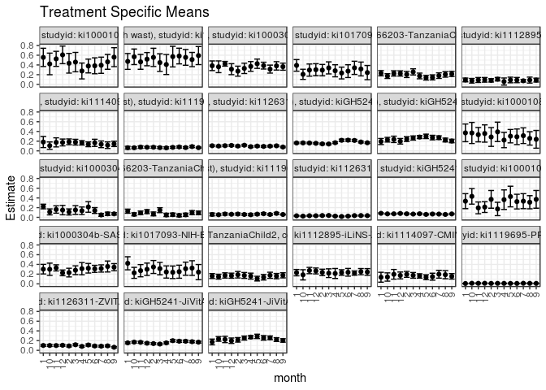

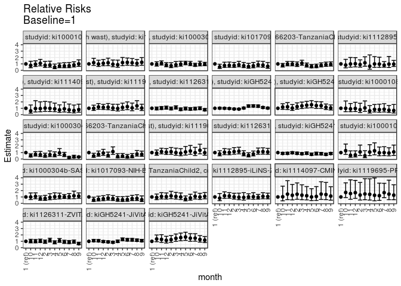

[figure not shown]

[figure not shown]

## Results Table

### Parameter: TSM

| agecat | studyid | country | intervention_level | baseline_level | estimate | ci_lower | ci_upper |
| --- | --- | --- | --- | --- | --- | --- | --- |
| 0-24 months (no birth wast) | ki1000108-CMC-V-BCS-2002 | INDIA | 1 | NA | 0.5555556 | 0.3678706 | 0.7432406 |
| 0-24 months (no birth wast) | ki1000108-CMC-V-BCS-2002 | INDIA | 2 | NA | 0.4347826 | 0.2319121 | 0.6376531 |
| 0-24 months (no birth wast) | ki1000108-CMC-V-BCS-2002 | INDIA | 3 | NA | 0.4583333 | 0.2587197 | 0.6579469 |
| 0-24 months (no birth wast) | ki1000108-CMC-V-BCS-2002 | INDIA | 4 | NA | 0.2758621 | 0.1129712 | 0.4387529 |
| 0-24 months (no birth wast) | ki1000108-CMC-V-BCS-2002 | INDIA | 5 | NA | 0.3777778 | 0.2359296 | 0.5196259 |
| 0-24 months (no birth wast) | ki1000108-CMC-V-BCS-2002 | INDIA | 6 | NA | 0.3823529 | 0.2187836 | 0.5459223 |
| 0-24 months (no birth wast) | ki1000108-CMC-V-BCS-2002 | INDIA | 7 | NA | 0.3939394 | 0.2270016 | 0.5608772 |
| 0-24 months (no birth wast) | ki1000108-CMC-V-BCS-2002 | INDIA | 8 | NA | 0.4634146 | 0.3105696 | 0.6162597 |
| 0-24 months (no birth wast) | ki1000108-CMC-V-BCS-2002 | INDIA | 9 | NA | 0.5600000 | 0.3651550 | 0.7548450 |
| 0-24 months (no birth wast) | ki1000108-CMC-V-BCS-2002 | INDIA | 10 | NA | 0.4210526 | 0.1987473 | 0.6433580 |
| 0-24 months (no birth wast) | ki1000108-CMC-V-BCS-2002 | INDIA | 11 | NA | 0.5250000 | 0.3700344 | 0.6799656 |
| 0-24 months (no birth wast) | ki1000108-CMC-V-BCS-2002 | INDIA | 12 | NA | 0.6071429 | 0.4259994 | 0.7882863 |
| 0-24 months (no birth wast) | ki1000108-IRC | INDIA | 1 | NA | 0.4722222 | 0.3089444 | 0.6355000 |
| 0-24 months (no birth wast) | ki1000108-IRC | INDIA | 2 | NA | 0.5555556 | 0.3678962 | 0.7432149 |
| 0-24 months (no birth wast) | ki1000108-IRC | INDIA | 3 | NA | 0.4482759 | 0.2670524 | 0.6294993 |
| 0-24 months (no birth wast) | ki1000108-IRC | INDIA | 4 | NA | 0.4090909 | 0.2033889 | 0.6147929 |
| 0-24 months (no birth wast) | ki1000108-IRC | INDIA | 5 | NA | 0.5714286 | 0.3595131 | 0.7833440 |
| 0-24 months (no birth wast) | ki1000108-IRC | INDIA | 6 | NA | 0.5833333 | 0.4220902 | 0.7445765 |
| 0-24 months (no birth wast) | ki1000108-IRC | INDIA | 7 | NA | 0.5555556 | 0.3930378 | 0.7180733 |
| 0-24 months (no birth wast) | ki1000108-IRC | INDIA | 8 | NA | 0.5111111 | 0.3648812 | 0.6573410 |
| 0-24 months (no birth wast) | ki1000108-IRC | INDIA | 9 | NA | 0.5925926 | 0.4070300 | 0.7781552 |
| 0-24 months (no birth wast) | ki1000108-IRC | INDIA | 10 | NA | 0.5675676 | 0.4077418 | 0.7273933 |
| 0-24 months (no birth wast) | ki1000108-IRC | INDIA | 11 | NA | 0.4634146 | 0.3105905 | 0.6162388 |
| 0-24 months (no birth wast) | ki1000108-IRC | INDIA | 12 | NA | 0.5192308 | 0.3832660 | 0.6551956 |
| 0-24 months (no birth wast) | ki1000304b-SAS-CompFeed | INDIA | 1 | NA | 0.3831776 | 0.2839910 | 0.4823642 |
| 0-24 months (no birth wast) | ki1000304b-SAS-CompFeed | INDIA | 2 | NA | 0.2717391 | 0.1689336 | 0.3745446 |
| 0-24 months (no birth wast) | ki1000304b-SAS-CompFeed | INDIA | 3 | NA | 0.3295455 | 0.2231786 | 0.4359123 |
| 0-24 months (no birth wast) | ki1000304b-SAS-CompFeed | INDIA | 4 | NA | 0.3690476 | 0.2686959 | 0.4693993 |
| 0-24 months (no birth wast) | ki1000304b-SAS-CompFeed | INDIA | 5 | NA | 0.4252874 | 0.3295151 | 0.5210596 |
| 0-24 months (no birth wast) | ki1000304b-SAS-CompFeed | INDIA | 6 | NA | 0.3859649 | 0.3154439 | 0.4564859 |

[output cut: 294 more lines]

### Parameter: E(Y)

| agecat | studyid | country | intervention_level | baseline_level | estimate | ci_lower | ci_upper |
| --- | --- | --- | --- | --- | --- | --- | --- |
| 0-24 months (no birth wast) | ki1000108-CMC-V-BCS-2002 | INDIA | NA | NA | 0.4510870 | 0.4001777 | 0.5019962 |
| 0-24 months (no birth wast) | ki1000108-IRC | INDIA | NA | NA | 0.5207824 | 0.4723080 | 0.5692568 |
| 0-24 months (no birth wast) | ki1000304b-SAS-CompFeed | INDIA | NA | NA | 0.3615180 | 0.3107193 | 0.4123167 |
| 0-24 months (no birth wast) | ki1017093-NIH-Birth | BANGLADESH | NA | NA | 0.2956811 | 0.2591967 | 0.3321655 |
| 0-24 months (no birth wast) | ki1066203-TanzaniaChild2 | TANZANIA, UNITED REPUBLIC OF | NA | NA | 0.1988255 | 0.1828010 | 0.2148500 |
| 0-24 months (no birth wast) | ki1112895-iLiNS-Zinc | BURKINA FASO | NA | NA | 0.0850857 | 0.0676201 | 0.1025513 |
| 0-24 months (no birth wast) | ki1114097-CMIN | GUINEA-BISSAU | NA | NA | 0.1573333 | 0.1389008 | 0.1757659 |
| 0-24 months (no birth wast) | ki1119695-PROBIT | BELARUS | NA | NA | 0.0716952 | 0.0597165 | 0.0836739 |
| 0-24 months (no birth wast) | ki1126311-ZVITAMBO | ZIMBABWE | NA | NA | 0.0997867 | 0.0947492 | 0.1048243 |
| 0-24 months (no birth wast) | kiGH5241-JiVitA-3 | BANGLADESH | NA | NA | 0.1693740 | 0.1640742 | 0.1746738 |
| 0-24 months (no birth wast) | kiGH5241-JiVitA-4 | BANGLADESH | NA | NA | 0.2577835 | 0.2441424 | 0.2714247 |
| 0-6 months (no birth wast) | ki1000108-CMC-V-BCS-2002 | INDIA | NA | NA | 0.3085714 | 0.2601110 | 0.3570318 |
| 0-6 months (no birth wast) | ki1000304b-SAS-CompFeed | INDIA | NA | NA | 0.1255940 | 0.0954030 | 0.1557851 |
| 0-6 months (no birth wast) | ki1066203-TanzaniaChild2 | TANZANIA, UNITED REPUBLIC OF | NA | NA | 0.0858586 | 0.0745914 | 0.0971258 |
| 0-6 months (no birth wast) | ki1119695-PROBIT | BELARUS | NA | NA | 0.0637570 | 0.0524446 | 0.0750694 |
| 0-6 months (no birth wast) | ki1126311-ZVITAMBO | ZIMBABWE | NA | NA | 0.0320114 | 0.0290240 | 0.0349988 |
| 0-6 months (no birth wast) | kiGH5241-JiVitA-3 | BANGLADESH | NA | NA | 0.0716899 | 0.0680353 | 0.0753445 |
| 6-24 months | ki1000108-IRC | INDIA | NA | NA | 0.3097561 | 0.2649438 | 0.3545684 |
| 6-24 months | ki1000304b-SAS-CompFeed | INDIA | NA | NA | 0.3059755 | 0.2638053 | 0.3481458 |
| 6-24 months | ki1017093-NIH-Birth | BANGLADESH | NA | NA | 0.2939002 | 0.2554778 | 0.3323226 |
| 6-24 months | ki1066203-TanzaniaChild2 | TANZANIA, UNITED REPUBLIC OF | NA | NA | 0.1605550 | 0.1445335 | 0.1765765 |
| 6-24 months | ki1112895-iLiNS-Zinc | BURKINA FASO | NA | NA | 0.2317820 | 0.2038933 | 0.2596707 |
| 6-24 months | ki1114097-CMIN | GUINEA-BISSAU | NA | NA | 0.1666667 | 0.1476863 | 0.1856470 |
| 6-24 months | ki1119695-PROBIT | BELARUS | NA | NA | 0.0100615 | 0.0072668 | 0.0128561 |
| 6-24 months | ki1126311-ZVITAMBO | ZIMBABWE | NA | NA | 0.0939843 | 0.0884477 | 0.0995208 |
| 6-24 months | kiGH5241-JiVitA-3 | BANGLADESH | NA | NA | 0.1640074 | 0.1578946 | 0.1701202 |
| 6-24 months | kiGH5241-JiVitA-4 | BANGLADESH | NA | NA | 0.2473297 | 0.2337864 | 0.2608729 |

### Parameter: RR

| agecat | studyid | country | intervention_level | baseline_level | estimate | ci_lower | ci_upper |
| --- | --- | --- | --- | --- | --- | --- | --- |
| 0-24 months (no birth wast) | ki1000108-CMC-V-BCS-2002 | INDIA | 1 | 1 | 1.0000000 | 1.0000000 | 1.0000000 |
| 0-24 months (no birth wast) | ki1000108-CMC-V-BCS-2002 | INDIA | 2 | 1 | 0.7826087 | 0.4399098 | 1.3922772 |
| 0-24 months (no birth wast) | ki1000108-CMC-V-BCS-2002 | INDIA | 3 | 1 | 0.8250000 | 0.4754180 | 1.4316349 |
| 0-24 months (no birth wast) | ki1000108-CMC-V-BCS-2002 | INDIA | 4 | 1 | 0.4965517 | 0.2514882 | 0.9804184 |
| 0-24 months (no birth wast) | ki1000108-CMC-V-BCS-2002 | INDIA | 5 | 1 | 0.6800000 | 0.4103465 | 1.1268524 |
| 0-24 months (no birth wast) | ki1000108-CMC-V-BCS-2002 | INDIA | 6 | 1 | 0.6882353 | 0.3990250 | 1.1870629 |
| 0-24 months (no birth wast) | ki1000108-CMC-V-BCS-2002 | INDIA | 7 | 1 | 0.7090909 | 0.4124171 | 1.2191780 |
| 0-24 months (no birth wast) | ki1000108-CMC-V-BCS-2002 | INDIA | 8 | 1 | 0.8341463 | 0.5202297 | 1.3374863 |
| 0-24 months (no birth wast) | ki1000108-CMC-V-BCS-2002 | INDIA | 9 | 1 | 1.0080000 | 0.6206441 | 1.6371122 |
| 0-24 months (no birth wast) | ki1000108-CMC-V-BCS-2002 | INDIA | 10 | 1 | 0.7578947 | 0.4049388 | 1.4184969 |
| 0-24 months (no birth wast) | ki1000108-CMC-V-BCS-2002 | INDIA | 11 | 1 | 0.9450000 | 0.6033920 | 1.4800081 |
| 0-24 months (no birth wast) | ki1000108-CMC-V-BCS-2002 | INDIA | 12 | 1 | 1.0928571 | 0.6963367 | 1.7151713 |
| 0-24 months (no birth wast) | ki1000108-IRC | INDIA | 1 | 1 | 1.0000000 | 1.0000000 | 1.0000000 |
| 0-24 months (no birth wast) | ki1000108-IRC | INDIA | 2 | 1 | 1.1764706 | 0.7255263 | 1.9076953 |
| 0-24 months (no birth wast) | ki1000108-IRC | INDIA | 3 | 1 | 0.9492901 | 0.5576606 | 1.6159500 |
| 0-24 months (no birth wast) | ki1000108-IRC | INDIA | 4 | 1 | 0.8663102 | 0.4705991 | 1.5947614 |
| 0-24 months (no birth wast) | ki1000108-IRC | INDIA | 5 | 1 | 1.2100840 | 0.7288078 | 2.0091763 |
| 0-24 months (no birth wast) | ki1000108-IRC | INDIA | 6 | 1 | 1.2352941 | 0.7934506 | 1.9231842 |
| 0-24 months (no birth wast) | ki1000108-IRC | INDIA | 7 | 1 | 1.1764706 | 0.7479703 | 1.8504518 |
| 0-24 months (no birth wast) | ki1000108-IRC | INDIA | 8 | 1 | 1.0823529 | 0.6909780 | 1.6954054 |
| 0-24 months (no birth wast) | ki1000108-IRC | INDIA | 9 | 1 | 1.2549020 | 0.7870786 | 2.0007900 |
| 0-24 months (no birth wast) | ki1000108-IRC | INDIA | 10 | 1 | 1.2019078 | 0.7694983 | 1.8773041 |
| 0-24 months (no birth wast) | ki1000108-IRC | INDIA | 11 | 1 | 0.9813486 | 0.6085706 | 1.5824708 |
| 0-24 months (no birth wast) | ki1000108-IRC | INDIA | 12 | 1 | 1.0995475 | 0.7126016 | 1.6966067 |
| 0-24 months (no birth wast) | ki1000304b-SAS-CompFeed | INDIA | 1 | 1 | 1.0000000 | 1.0000000 | 1.0000000 |
| 0-24 months (no birth wast) | ki1000304b-SAS-CompFeed | INDIA | 2 | 1 | 0.7091729 | 0.4222443 | 1.1910786 |
| 0-24 months (no birth wast) | ki1000304b-SAS-CompFeed | INDIA | 3 | 1 | 0.8600333 | 0.5405112 | 1.3684401 |
| 0-24 months (no birth wast) | ki1000304b-SAS-CompFeed | INDIA | 4 | 1 | 0.9631243 | 0.6546652 | 1.4169203 |
| 0-24 months (no birth wast) | ki1000304b-SAS-CompFeed | INDIA | 5 | 1 | 1.1098963 | 0.8657312 | 1.4229240 |
| 0-24 months (no birth wast) | ki1000304b-SAS-CompFeed | INDIA | 6 | 1 | 1.0072743 | 0.7306083 | 1.3887079 |

[output cut: 294 more lines]

### Parameter: PAR

| agecat | studyid | country | intervention_level | baseline_level | estimate | ci_lower | ci_upper |
| --- | --- | --- | --- | --- | --- | --- | --- |
| 0-24 months (no birth wast) | ki1000108-CMC-V-BCS-2002 | INDIA | 1 | NA | -0.1044686 | -0.2851574 | 0.0762202 |
| 0-24 months (no birth wast) | ki1000108-IRC | INDIA | 1 | NA | 0.0485602 | -0.1073766 | 0.2044969 |
| 0-24 months (no birth wast) | ki1000304b-SAS-CompFeed | INDIA | 1 | NA | -0.0216596 | -0.1164395 | 0.0731203 |
| 0-24 months (no birth wast) | ki1017093-NIH-Birth | BANGLADESH | 1 | NA | -0.0949439 | -0.2071918 | 0.0173039 |
| 0-24 months (no birth wast) | ki1066203-TanzaniaChild2 | TANZANIA, UNITED REPUBLIC OF | 1 | NA | -0.0306117 | -0.0818765 | 0.0206531 |
| 0-24 months (no birth wast) | ki1112895-iLiNS-Zinc | BURKINA FASO | 1 | NA | -0.0062186 | -0.0443328 | 0.0318956 |
| 0-24 months (no birth wast) | ki1114097-CMIN | GUINEA-BISSAU | 1 | NA | -0.0244848 | -0.1366170 | 0.0876473 |
| 0-24 months (no birth wast) | ki1119695-PROBIT | BELARUS | 1 | NA | 0.0073974 | -0.0153462 | 0.0301410 |
| 0-24 months (no birth wast) | ki1126311-ZVITAMBO | ZIMBABWE | 1 | NA | -0.0054764 | -0.0211037 | 0.0101509 |
| 0-24 months (no birth wast) | kiGH5241-JiVitA-3 | BANGLADESH | 1 | NA | 0.0070286 | -0.0067153 | 0.0207724 |
| 0-24 months (no birth wast) | kiGH5241-JiVitA-4 | BANGLADESH | 1 | NA | 0.0648011 | 0.0022516 | 0.1273506 |
| 0-6 months (no birth wast) | ki1000108-CMC-V-BCS-2002 | INDIA | 1 | NA | -0.0617989 | -0.2364075 | 0.1128096 |
| 0-6 months (no birth wast) | ki1000304b-SAS-CompFeed | INDIA | 1 | NA | -0.0977069 | -0.1409469 | -0.0544670 |
| 0-6 months (no birth wast) | ki1066203-TanzaniaChild2 | TANZANIA, UNITED REPUBLIC OF | 1 | NA | -0.0407790 | -0.0810935 | -0.0004644 |
| 0-6 months (no birth wast) | ki1119695-PROBIT | BELARUS | 1 | NA | 0.0045295 | -0.0196755 | 0.0287345 |
| 0-6 months (no birth wast) | ki1126311-ZVITAMBO | ZIMBABWE | 1 | NA | -0.0002963 | -0.0094235 | 0.0088310 |
| 0-6 months (no birth wast) | kiGH5241-JiVitA-3 | BANGLADESH | 1 | NA | -0.0110047 | -0.0214033 | -0.0006061 |
| 6-24 months | ki1000108-IRC | INDIA | 1 | NA | -0.0235772 | -0.1705618 | 0.1234073 |
| 6-24 months | ki1000304b-SAS-CompFeed | INDIA | 1 | NA | 0.0038922 | -0.0923495 | 0.1001339 |
| 6-24 months | ki1017093-NIH-Birth | BANGLADESH | 1 | NA | -0.1291767 | -0.2559378 | -0.0024156 |
| 6-24 months | ki1066203-TanzaniaChild2 | TANZANIA, UNITED REPUBLIC OF | 1 | NA | -0.0002490 | -0.0487148 | 0.0482168 |
| 6-24 months | ki1112895-iLiNS-Zinc | BURKINA FASO | 1 | NA | 0.0016565 | -0.0731319 | 0.0764449 |
| 6-24 months | ki1114097-CMIN | GUINEA-BISSAU | 1 | NA | 0.0303030 | -0.0698875 | 0.1304936 |
| 6-24 months | ki1119695-PROBIT | BELARUS | 1 | NA | 0.0030867 | -0.0009227 | 0.0070961 |
| 6-24 months | ki1126311-ZVITAMBO | ZIMBABWE | 1 | NA | -0.0062048 | -0.0233251 | 0.0109155 |
| 6-24 months | kiGH5241-JiVitA-3 | BANGLADESH | 1 | NA | 0.0101612 | -0.0086744 | 0.0289969 |
| 6-24 months | kiGH5241-JiVitA-4 | BANGLADESH | 1 | NA | 0.0749159 | 0.0150108 | 0.1348209 |

### Parameter: PAF

| agecat | studyid | country | intervention_level | baseline_level | estimate | ci_lower | ci_upper |
| --- | --- | --- | --- | --- | --- | --- | --- |
| 0-24 months (no birth wast) | ki1000108-CMC-V-BCS-2002 | INDIA | 1 | NA | -0.2315930 | -0.7061795 | 0.1109837 |
| 0-24 months (no birth wast) | ki1000108-IRC | INDIA | 1 | NA | 0.0932447 | -0.2617139 | 0.3483426 |
| 0-24 months (no birth wast) | ki1000304b-SAS-CompFeed | INDIA | 1 | NA | -0.0599129 | -0.3594571 | 0.1736294 |
| 0-24 months (no birth wast) | ki1017093-NIH-Birth | BANGLADESH | 1 | NA | -0.3211025 | -0.7611940 | 0.0090178 |
| 0-24 months (no birth wast) | ki1066203-TanzaniaChild2 | TANZANIA, UNITED REPUBLIC OF | 1 | NA | -0.1539628 | -0.4427175 | 0.0769987 |
| 0-24 months (no birth wast) | ki1112895-iLiNS-Zinc | BURKINA FASO | 1 | NA | -0.0730865 | -0.6332431 | 0.2949521 |
| 0-24 months (no birth wast) | ki1114097-CMIN | GUINEA-BISSAU | 1 | NA | -0.1556240 | -1.1409566 | 0.3762289 |
| 0-24 months (no birth wast) | ki1119695-PROBIT | BELARUS | 1 | NA | 0.1031785 | -0.2860008 | 0.3745814 |
| 0-24 months (no birth wast) | ki1126311-ZVITAMBO | ZIMBABWE | 1 | NA | -0.0548811 | -0.2236886 | 0.0906394 |
| 0-24 months (no birth wast) | kiGH5241-JiVitA-3 | BANGLADESH | 1 | NA | 0.0414972 | -0.0432302 | 0.1193435 |
| 0-24 months (no birth wast) | kiGH5241-JiVitA-4 | BANGLADESH | 1 | NA | 0.2513779 | -0.0334536 | 0.4577066 |
| 0-6 months (no birth wast) | ki1000108-CMC-V-BCS-2002 | INDIA | 1 | NA | -0.2002743 | -0.9233053 | 0.2509465 |
| 0-6 months (no birth wast) | ki1000304b-SAS-CompFeed | INDIA | 1 | NA | -0.7779585 | -1.2541560 | -0.4023593 |
| 0-6 months (no birth wast) | ki1066203-TanzaniaChild2 | TANZANIA, UNITED REPUBLIC OF | 1 | NA | -0.4749550 | -1.0237239 | -0.0749947 |
| 0-6 months (no birth wast) | ki1119695-PROBIT | BELARUS | 1 | NA | 0.0710434 | -0.4046517 | 0.3856410 |
| 0-6 months (no birth wast) | ki1126311-ZVITAMBO | ZIMBABWE | 1 | NA | -0.0092560 | -0.3387311 | 0.2391320 |
| 0-6 months (no birth wast) | kiGH5241-JiVitA-3 | BANGLADESH | 1 | NA | -0.1535044 | -0.3081537 | -0.0171377 |
| 6-24 months | ki1000108-IRC | INDIA | 1 | NA | -0.0761155 | -0.6724799 | 0.3076003 |
| 6-24 months | ki1000304b-SAS-CompFeed | INDIA | 1 | NA | 0.0127206 | -0.3573086 | 0.2818725 |
| 6-24 months | ki1017093-NIH-Birth | BANGLADESH | 1 | NA | -0.4395259 | -0.9434367 | -0.0662734 |
| 6-24 months | ki1066203-TanzaniaChild2 | TANZANIA, UNITED REPUBLIC OF | 1 | NA | -0.0015510 | -0.3538419 | 0.2590683 |
| 6-24 months | ki1112895-iLiNS-Zinc | BURKINA FASO | 1 | NA | 0.0071467 | -0.3735316 | 0.2823189 |
| 6-24 months | ki1114097-CMIN | GUINEA-BISSAU | 1 | NA | 0.1818182 | -0.7053437 | 0.6074566 |
| 6-24 months | ki1119695-PROBIT | BELARUS | 1 | NA | 0.3067883 | -0.2442038 | 0.6137751 |
| 6-24 months | ki1126311-ZVITAMBO | ZIMBABWE | 1 | NA | -0.0660193 | -0.2646318 | 0.1014007 |
| 6-24 months | kiGH5241-JiVitA-3 | BANGLADESH | 1 | NA | 0.0619560 | -0.0603193 | 0.1701306 |
| 6-24 months | kiGH5241-JiVitA-4 | BANGLADESH | 1 | NA | 0.3028988 | 0.0154577 | 0.5064203 |